# University of Washington Graduation Rate

James Lamar Foster, Ph.D. Candidate

August 20, 2021

# **Summary of Findings**

*University of Washington’s Graduate Rate*

- 4-year graduation rate is 66%
- 6-year graduation rate is 84%
- Women overall graduation rate is 87%
- Men overall graduation rate is 81%

This project uses data from the [Integrated Postsecondary Education Data System (IPEDS)](https://nces.ed.gov/ipeds/) to examine how the University of Washington - Seattle compares to similar institutions in the West regarding graduation.

Four and six-year graduation rates were examined for class of 2019. This exploratory analysis discovered that the University of Washington’s 4-year and 6-year graduation rate ranks 5th among the 13 institutions in the Bureau of Economic Analysis (BEA) Far West region.

When the graduation rate was disaggregated by sex, the University of Washington’s graduation rate decreased to sixth place for men. However, the University of Washington remained in 5th place for women, although the graduation percentage for males is lower than females’ graduation percentage.

Analysts must do further disaggregation and analysis to understand the nuances of the University of Washington’s graduation rate. For example, IPEDS provides Pell and race/ethnicity data, which may lend itself well to a deeper analysis. This may deepen our understanding of which groups of people need more support to help them graduate within 4 or 6 years.

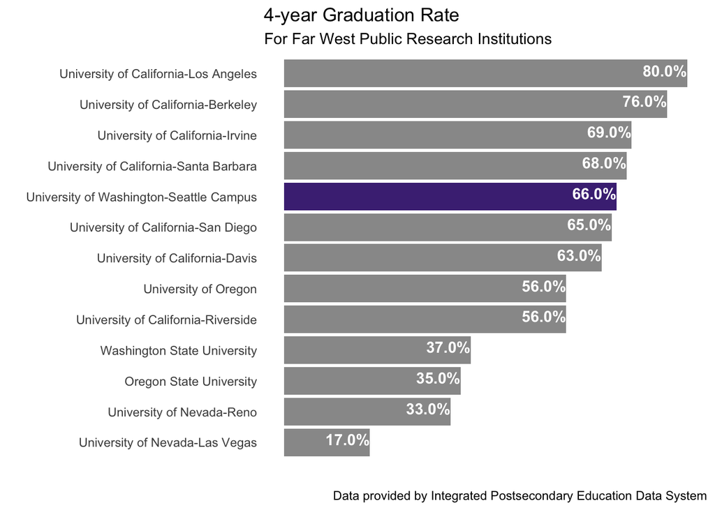

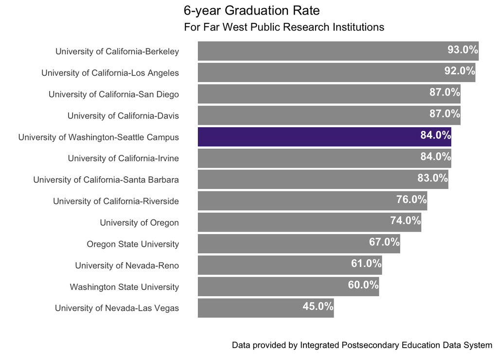

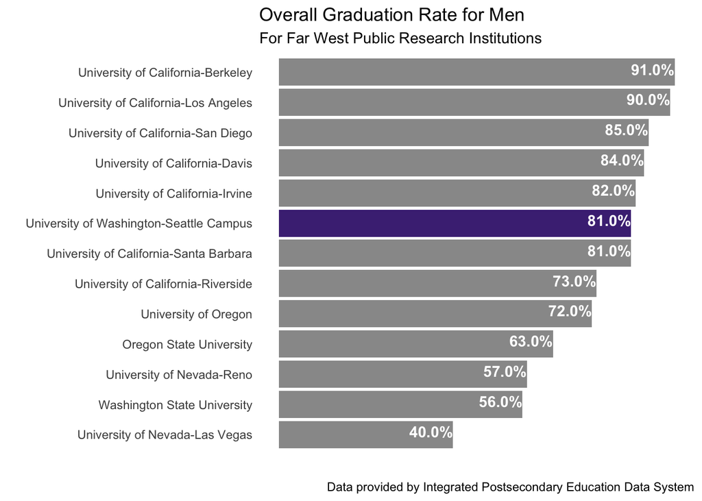

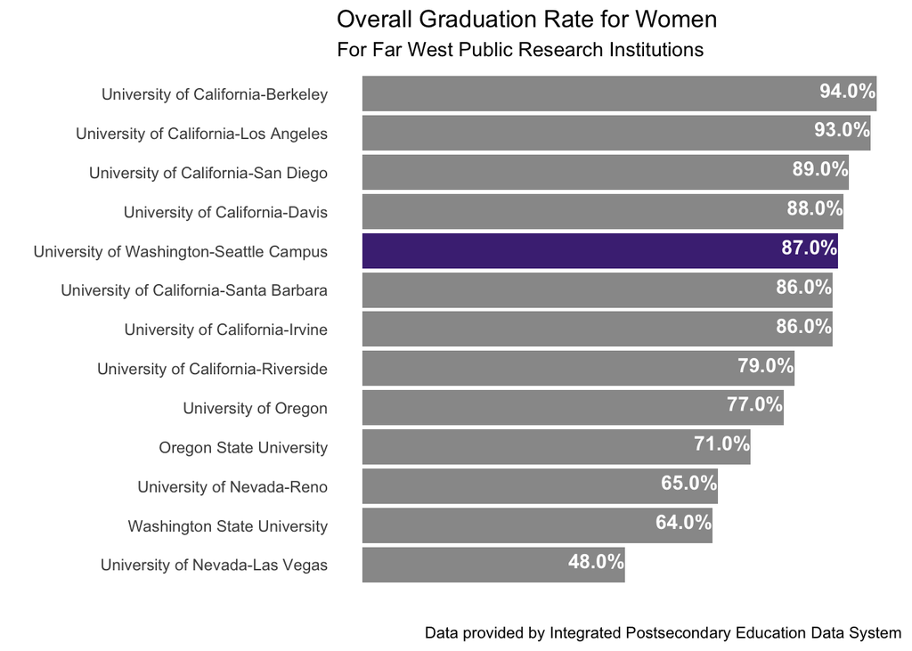

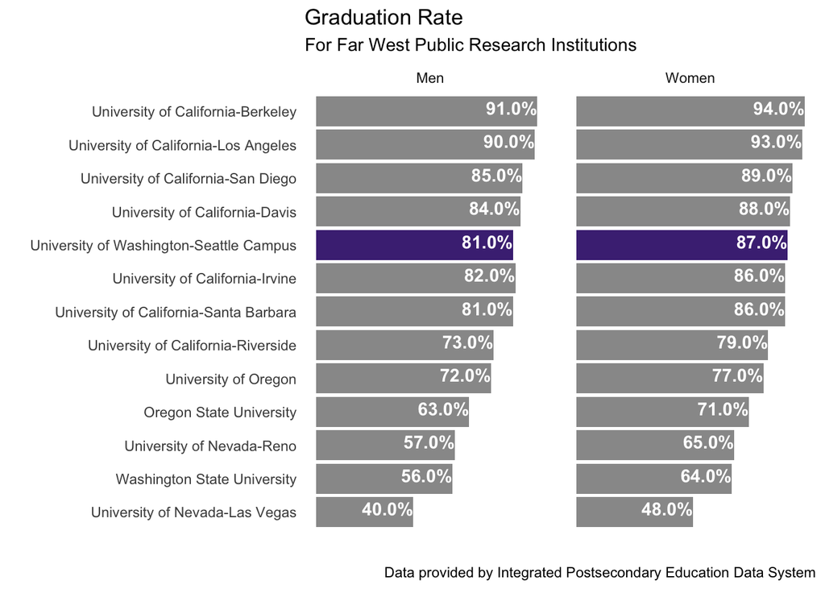